(1.57 xG) **Barcelona** 1 - 3 **Real Madrid** (3.21 xG)

La Liga 2020-2021: Matchday 5 (Oct. 24, 2020)

Minute

Team

Player

Result

Shot Map

Cumulative xG

Situation

Shot Type

Assist Player

Assist Action

4

Real Madrid

Federico Valverde

GOAL ⚽

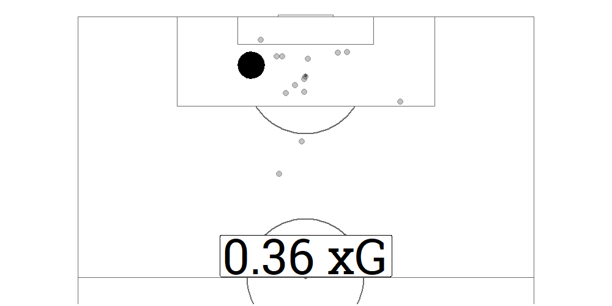

0.36

Open Play

Right Foot

Karim Benzema

Through ball

7

Barcelona

Anssumane Fati

GOAL ⚽

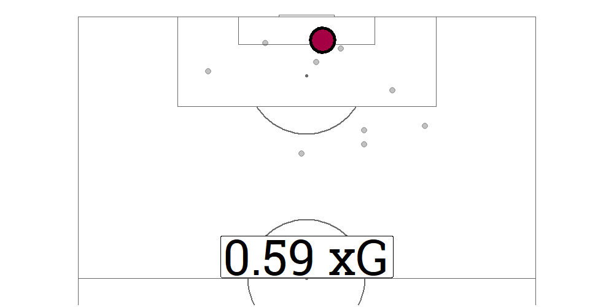

0.59

Open Play

Right Foot

Jordi Alba

Pass

12

Barcelona

Philippe Coutinho

Blocked Shot

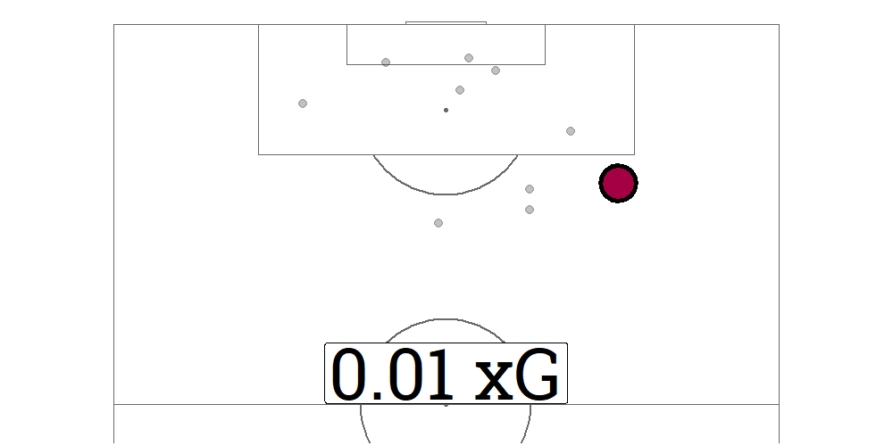

0.60

Set Piece

Right Foot

14

Barcelona

Philippe Coutinho

Saved Shot

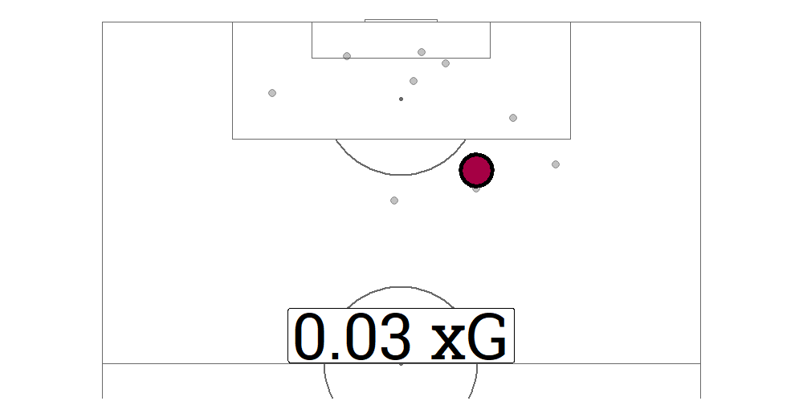

0.63

Open Play

Right Foot

Sergiño Dest

Pass

18

Barcelona

Lionel Messi

Saved Shot

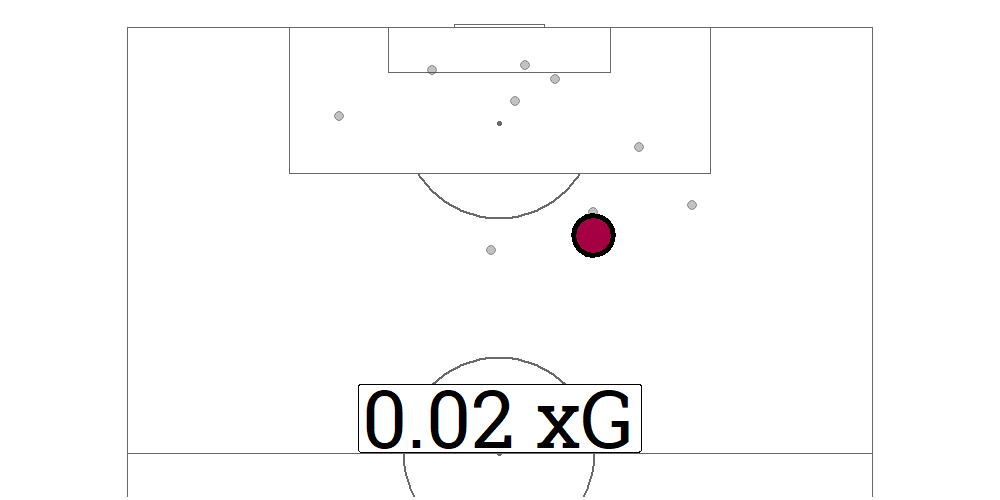

0.65

Open Play

Left Foot

Frenkie de Jong

Take On

22

Real Madrid

Raphael Varane

Blocked Shot

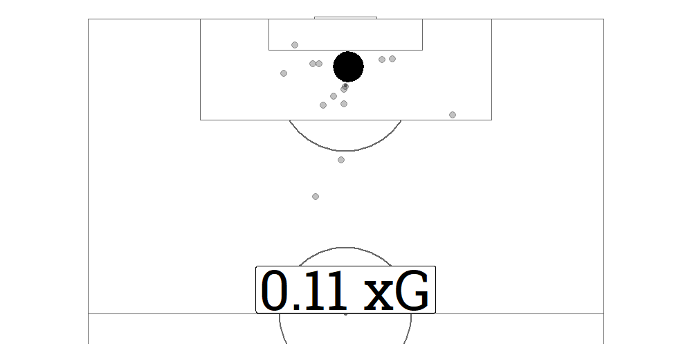

0.47

From Corner

Head

Toni Kroos

Cross

22

Real Madrid

Sergio Ramos

Saved Shot

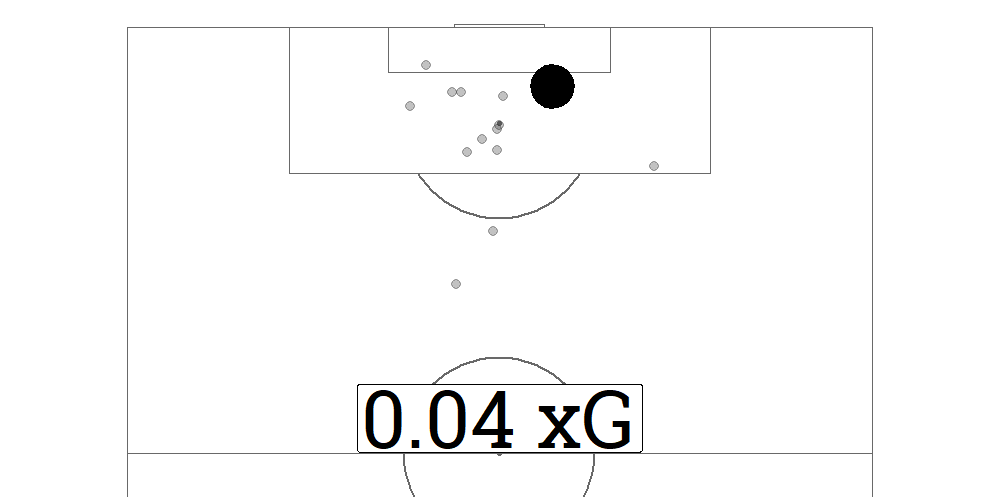

0.51

From Corner

Head

Toni Kroos

Aerial

23

Barcelona

Lionel Messi

Saved Shot

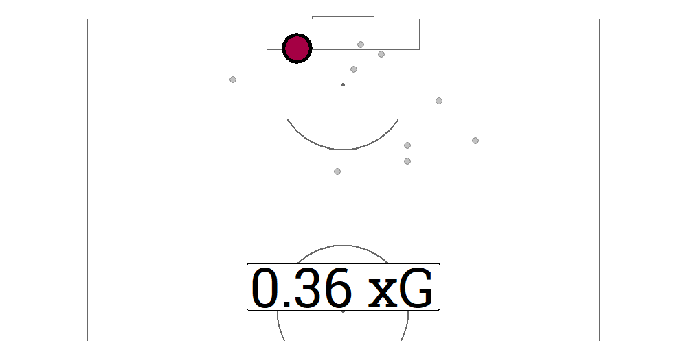

1.01

Open Play

Right Foot

Anssumane Fati

Take On

23

Real Madrid

Karim Benzema

Saved Shot

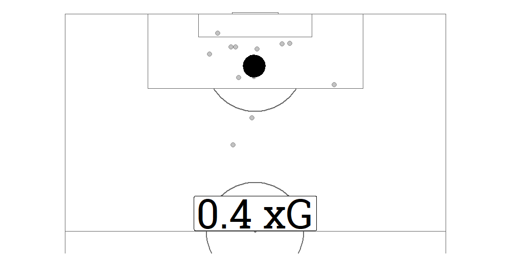

0.91

Open Play

Right Foot

Toni Kroos

Pass

35

Real Madrid

Karim Benzema

Blocked Shot

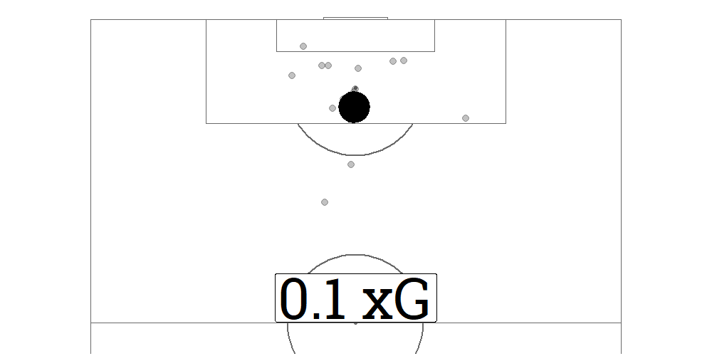

1.00

Open Play

Right Foot

Casemiro

Pass

47

Real Madrid

Sergio Ramos

Missed Shot

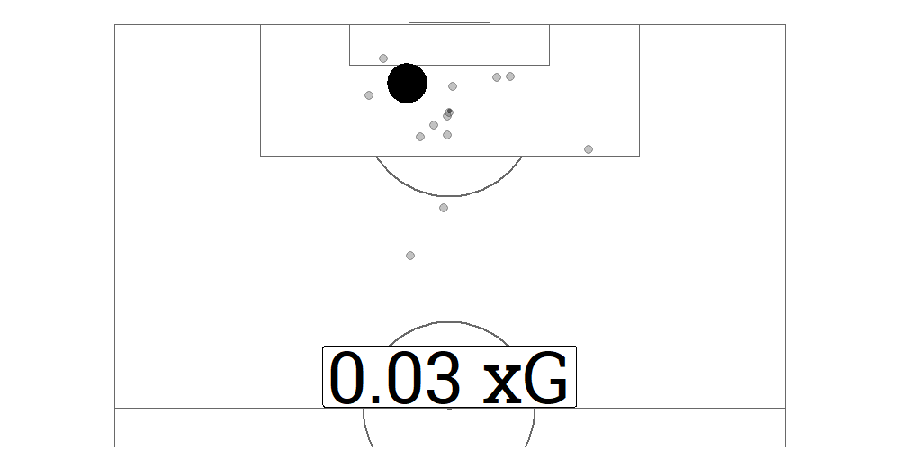

1.04

From Corner

Head

Toni Kroos

Aerial

50

Real Madrid

Casemiro Casemiro

Missed Shot

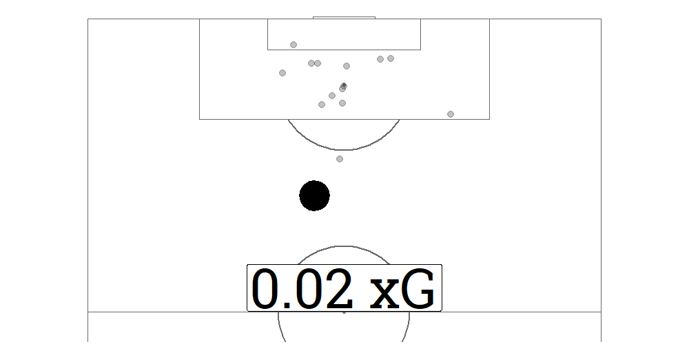

1.05

Open Play

Right Foot

Toni Kroos

Pass

51

Barcelona

Anssumane Fati

Missed Shot

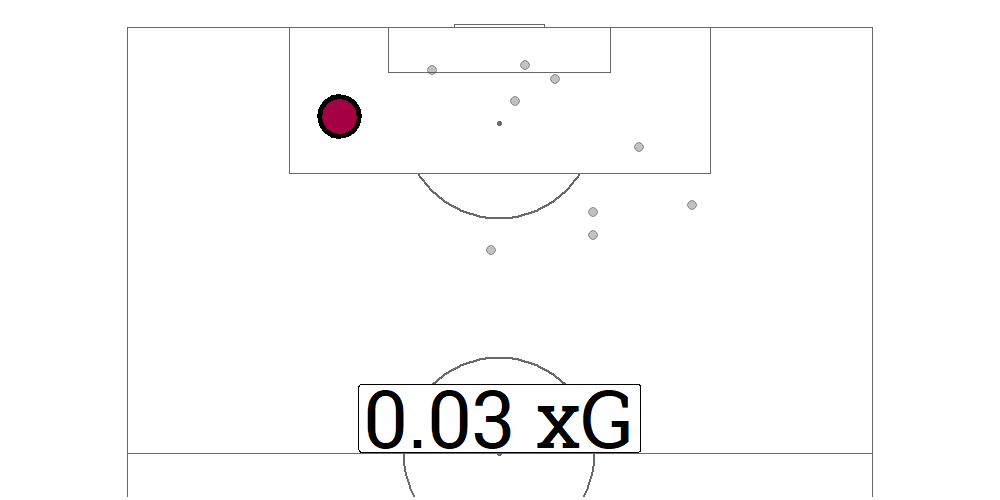

1.05

Open Play

Right Foot

Lionel Messi

Pass

53

Barcelona

Philippe Coutinho

Missed Shot

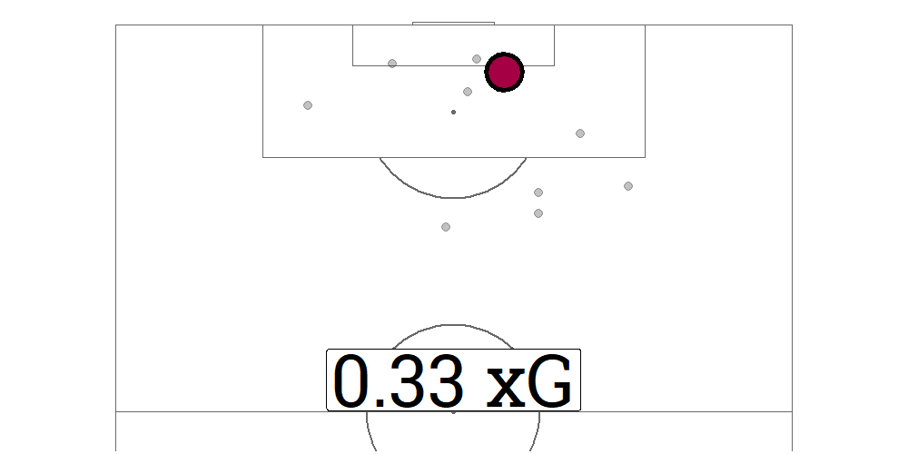

1.38

Open Play

Head

Anssumane Fati

Cross

56

Real Madrid

Karim Benzema

Missed Shot

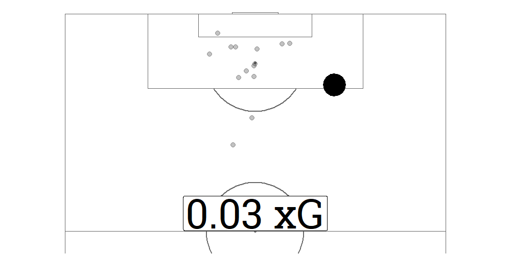

1.08

Open Play

Right Foot

Vinícius Júnior

Pass

62

Real Madrid

Sergio Ramos

GOAL ⚽

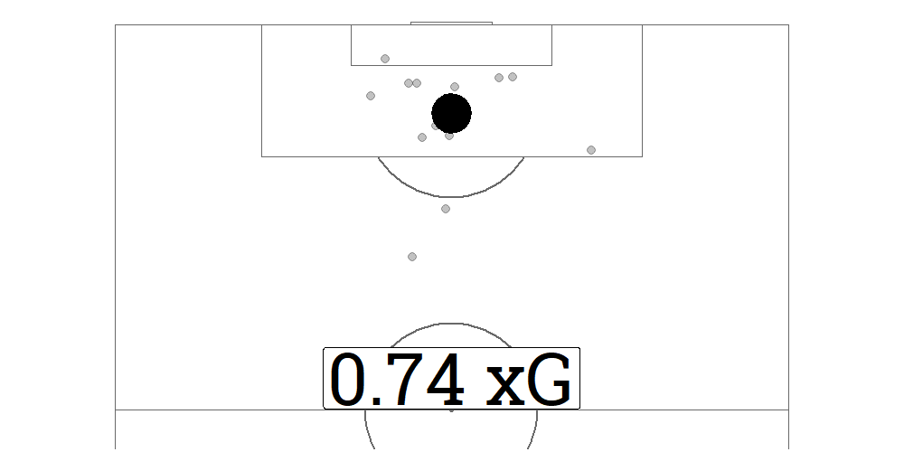

1.82

Penalty

Right Foot

66

Barcelona

Philippe Coutinho

Blocked Shot

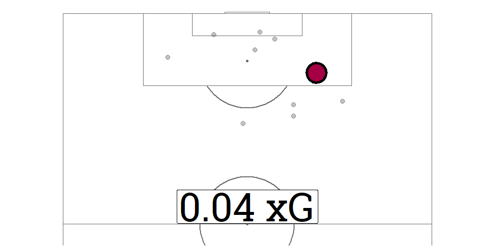

1.41

Open Play

Left Foot

Frenkie de Jong

Take On

69

Barcelona

Philippe Coutinho

Blocked Shot

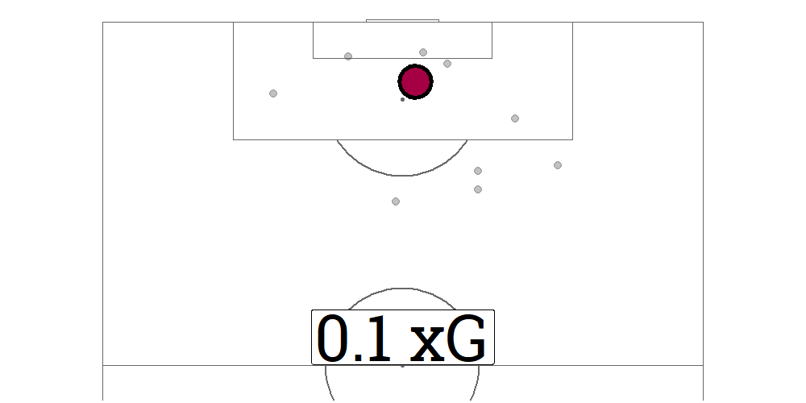

1.51

From Corner

Right Foot

78

Barcelona

Lionel Messi

Blocked Shot

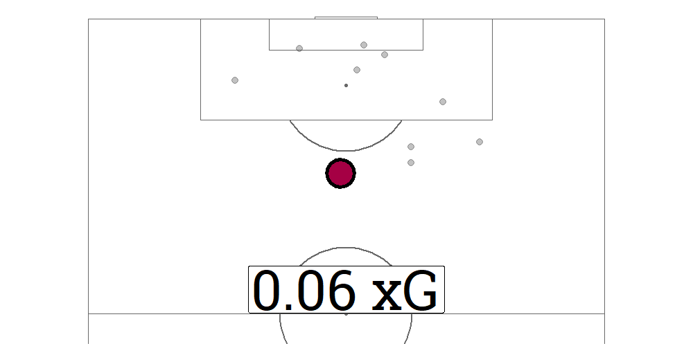

1.57

From Free Kick

Left Foot

85

Real Madrid

Toni Kroos

Saved Shot

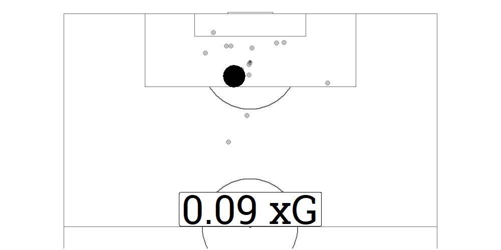

1.92

Open Play

Right Foot

Lucas Vázquez

Pass

85

Real Madrid

Toni Kroos

Saved Shot

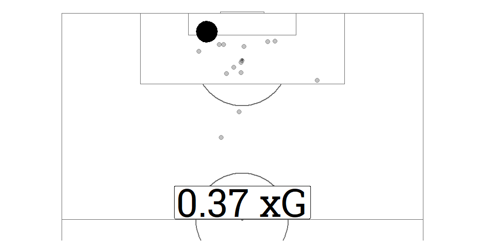

2.29

Open Play

Right Foot

Rebound

85

Real Madrid

Sergio Ramos

Saved Shot

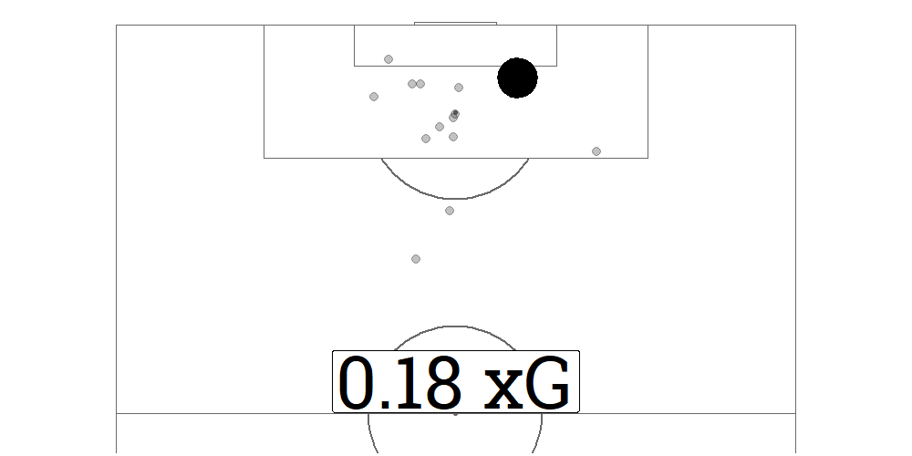

2.47

From Corner

Left Foot

Lucas Vázquez

Chipped

85

Real Madrid

Raphael Varane

Missed Shot

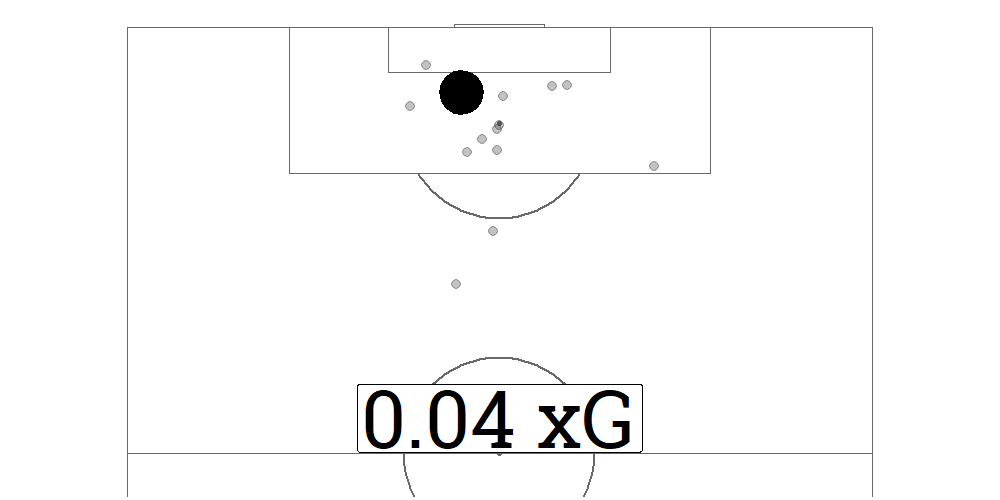

2.52

From Corner

Head

Rebound

86

Real Madrid

Vinícius Júnior

Saved Shot

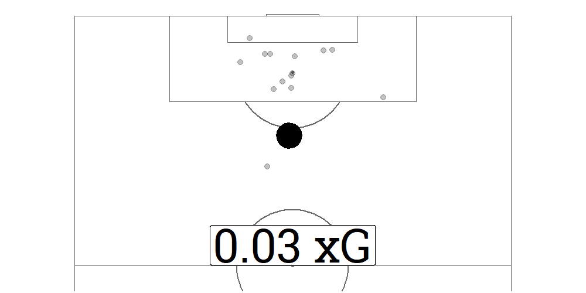

2.55

Open Play

Right Foot

Luka Modric

Pass

89

Real Madrid

Luka Modric

GOAL ⚽

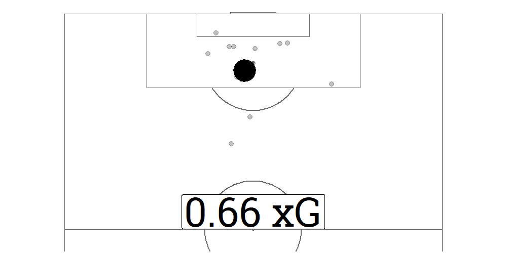

3.21

Open Play

Right Foot

Rodrygo

Take On

**Table**: Ryo Nakagawara (**Twitter**: @R_by_Ryo) | **Data**: understat